# ANÁLISIS ESTADISTICO DEL ABONO DE PORCINAZA Y DENSIDADES OBTIMAS DE SIEMBRA SOBRE EL RENDIMIENTO DE MAÍZ MORADO (Zea mays L.) var. INIA-601.

Author

Tomada de Zagaceta Llanca (2023)

[figure not shown]

# 1 INTEGRANTES G1

1. Colunche Vasquez Josue Jhonatan
2. Huaman Rimarachin Milver
3. Maicelo Villanueva Luis Miguel
4. Rivera Jimenez Yanet
5. Vasquez Barboza Erik Percy
6. Villa Tochon Jorge Luis<

# 2 INTRODUCCIÓN

El maíz morado es un cultivo de relevancia económica y nutricional en el Perú. Sin embargo, su rendimiento depende de factores agronómicos como la densidad de siembra y el manejo de la fertilización orgánica.En este contexto, la porcinaza constituye una alternativa sostenible que puede mejorar la productividad y la salud del suelo (Nolasco-Bernardo,2022). A través de herramientas estadísticas y gráficas en R Studio, se busca reproducir el análisis de varianza (ANOVA), la comparación de medias y la visualización de los resultados, verificando la consistencia con los hallazgos reportados en la investigación original. El presente trabajo tomado de Zagaceta Llanca (2023) el cual tuvo como finalidad analizar estadísticamente los datos experimentales provenientes del estudio “Niveles de porcinaza y densidades de siembra sobre el rendimiento de maíz morado (Zea mays L.) var. INIA-601 en Lámud”, en base a ello se tomo tomo tres variables a evaluar buscando contrastar los resultados originales de la tesis con los obtenidos mediante el procesamiento en R Studio.

# 3 OBJETIVOS

## 3.1 General

# 4 Estructura para el desarrollo del trabajo

1.Organizar los datos experimentales en una base de datos estructurada en formato CSV o Google Sheets.

2.Importar y verificar correctamente los factores experimentales en R Studio (porcinaza, densidad y bloque).

3.Realizar el análisis de varianza (ANOVA) para cada variable evaluada.

4.Efectuar la comparación de medias mediante la prueba de Tukey.

5.Representar los resultados de manera gráfica para visualizar las diferencias entre tratamientos.

# 5 DESARROLLO

## 5.1 Recolección y organización de datos

Los datos experimentales fueron recolectados del anexo de la tesis y organizados en una hoja de calculo google sheet el cual contiene los factores y variables evaluadas:

### 5.1.1 Factores

- Nivel de porcinaza (0, 160, 320 y 480 g/planta)
- Densidad de siembra (0.8×0.4 m y 0.8×0.5 m).

### 5.1.2 Bloques: 4 repeticiones.

### 5.1.3 Variables

- Altura de planta
- Número de mazorcas por planta
- Longitud, diámetro y peso de mazorca
- Altura de inserción de mazorca
- Número de mazorcas por hectárea
- Rendimiento de grano por hectárea.

### 5.1.4 Variables tomadas para la evaluación

- Rendimiento granos por hectarea
- Altura de planta a los 30 y 180 días
- Numero de mazorcas por planta

## 5.2 Librerías

```r
library(tidyverse)
library(googlesheets4)
library(lme4)
library(emmeans)
library(FactoMineR)
library(multcomp)
library(car)
library(cowplot)
library(GGally)
```

# 6 IMPORTAR BASE DE DATOS

```r
url <- "https://docs.google.com/spreadsheets/d/1o4mtAkI1lBgoUzqDT-e7cIhIwh_K5m6CoxAx0ETvwXU/edit?gid=1753270824#gid=1753270824"

gs <- url %>%
  as_sheets_id()

fb <- gs %>%
  range_read("fb") %>%
  mutate(across(c(tratamientos:bloque), factor))

str(fb)
```

```
tibble [32 × 13] (S3: tbl_df/tbl/data.frame)
 $ tratamientos: Factor w/ 8 levels "T1","T2","T3",..: 1 2 3 4 5 6 7 8 1 2 ...
 $ densidad    : Factor w/ 2 levels "0.8x0.4","0.8x0.5": 1 1 1 1 2 2 2 2 1 1 ...
 $ porcinaza   : Factor w/ 4 levels "0","160","320",..: 1 2 3 4 1 2 3 4 1 2 ...
 $ bloque      : Factor w/ 4 levels "I","II","III",..: 1 1 1 1 1 1 1 1 2 2 ...
 $ altu30d     : num [1:32] 23.1 20 23.4 26.2 20.7 24.5 23.1 23 23.5 25.7 ...
 $ alt180d     : num [1:32] 193 196 199 202 189 ...
 $ maz_p       : num [1:32] 1.1 1.1 1.1 1.4 1.3 1.4 1.5 1.8 1 1.1 ...
 $ long_m      : num [1:32] 12.3 14 14.4 16.1 13 16.3 16.8 21.4 12.2 13.9 ...
 $ diam_m      : num [1:32] 4.5 4.4 4.8 5 4.9 5.2 5.4 6 4.4 4.7 ...
 $ peso_g_m    : num [1:32] 89.6 100.6 109.4 132.8 112.8 ...
 $ aim180      : num [1:32] 82 81.4 79.7 93.2 99 ...
 $ maz_ha      : num [1:32] 35156 35156 35156 42969 31250 ...
 $ rend_g_ha   : num [1:32] 2801 3145 3418 4148 2819 ...
```

# 7 VARIABLES EVALUADAS

## 7.1 VARIABLE 1 Rendimiento de granos por hectarea

### 7.1.1 Modelo estadisticos rendimiento de granos por hectarea

$$Rend_g_ha = \mu + bloque + porcinaza + densidad + porcinaza*densidad + e$$
### Análisis de varianza Anova rendimiento de granos por hectarea

```r
modelo_rend <- aov(rend_g_ha ~ bloque + porcinaza * densidad, data = fb)
anova_rend <- anova(modelo_rend)
print(anova_rend)
```

```
Analysis of Variance Table

Response: rend_g_ha
                   Df   Sum Sq Mean Sq  F value    Pr(>F)
bloque              3    74043   24681   1.0921    0.3743
porcinaza           3 16925346 5641782 249.6333 < 2.2e-16 ***
densidad            1  1223048 1223048  54.1165 3.075e-07 ***
porcinaza:densidad  3  1755063  585021  25.8856 2.993e-07 ***
Residuals          21   474606   22600
---
Signif. codes:  0 '***' 0.001 '**' 0.01 '*' 0.05 '.' 0.1 ' ' 1
```

El análisis mostró que los factores porcinaza y densidad tuvieron un efecto altamente significativo sobre el rendimiento del cultivo (p < 0.001). Asimismo, la interacción porcinaza × densidad fue significativa, indicando que la respuesta del rendimiento a la porcinaza depende del nivel de densidad empleado. En cambio, el factor bloque no presentó diferencias significativas

### 7.1.2 Comparación de medias rendimiento de granos por hectarea

```r
tukey <- emmeans(modelo_rend, ~ porcinaza*densidad) %>%
  cld(adjust = "tukey", Letters = letters)

print(tukey)
```

```
 porcinaza densidad emmean   SE df lower.CL upper.CL .group
 0         0.8x0.5    2654 75.2 21     2426     2882  a
 0         0.8x0.4    2888 75.2 21     2660     3116  a
 160       0.8x0.4    3420 75.2 21     3192     3648   b
 320       0.8x0.4    3477 75.2 21     3249     3704   b
 160       0.8x0.5    3547 75.2 21     3319     3775   b
 480       0.8x0.4    4408 75.2 21     4181     4636    c
 320       0.8x0.5    4417 75.2 21     4190     4645    c
 480       0.8x0.5    5139 75.2 21     4911     5366     d

Results are averaged over the levels of: bloque
Confidence level used: 0.95
Conf-level adjustment: sidak method for 8 estimates
P value adjustment: tukey method for comparing a family of 8 estimates
significance level used: alpha = 0.05
NOTE: If two or more means share the same grouping symbol,
      then we cannot show them to be different.
      But we also did not show them to be the same.
```

### 7.1.3 Gráficos de rendimiento de granos por hectarea

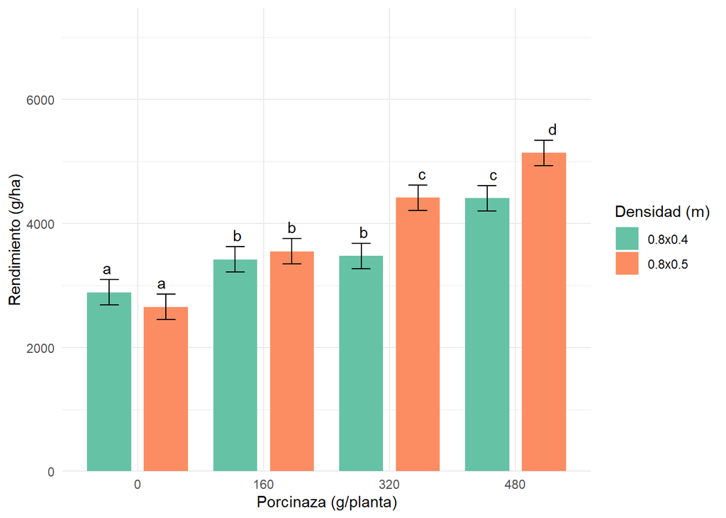

```r
emmeans_rend <- emmeans(modelo_rend, ~ porcinaza | densidad)
cld_rend <- cld(emmeans_rend, adjust = "tukey", Letters = letters)

ggplot(cld_rend, aes(x = porcinaza, y = emmean, fill = densidad)) +
  geom_col(position = position_dodge(0.9), width = 0.7) +
  geom_errorbar(aes(ymin = lower.CL, ymax = upper.CL),
                position = position_dodge(0.9), width = 0.3) +
  geom_text(aes(label = .group, y = upper.CL),
            position = position_dodge(0.9), vjust = -0.5) +
  labs(x = "Porcinaza (g/planta)", y = "Rendimiento (g/ha)", fill = "Densidad (m)") +
  scale_fill_brewer(type = "qual", palette = "Set2") +
  scale_y_continuous(expand = expansion(mult = c(0, 0.4)), limits = c(0, NA)) +
  theme_minimal()
```

Gráfico 01: El gráfico evidencia que el rendimiento de grano aumentó conforme se incrementó el nivel de porcinaza aplicado, tanto en la densidad de 0.8 × 0.4 m como en 0.8 × 0.5 m. Las letras sobre las barras muestran diferencias estadísticas entre los tratamientos.

## 7.2 VARIABLE 2 1 Altura de planta a los 30 días

### 7.2.1 Modelo estadisticos altura de planta a los 30 días

$$Altup30d = \mu + bloque + porcinaza + densidad + porcinaza*densidad + e$$

### 7.2.2 Análisis de varianza Anova altura de planta a los 30 días

```r
md_altu30d <- lmer(altu30d ~ densidad * porcinaza + (1 | bloque), data = fb)

Anova(md_altu30d)
```

```
Analysis of Deviance Table (Type II Wald chisquare tests)

Response: altu30d
                    Chisq Df Pr(>Chisq)
densidad           0.2935  1     0.5880
porcinaza          0.1345  3     0.9874
densidad:porcinaza 0.1075  3     0.9909
```

Ningún factor ni combinación de factores tuvo un efecto notable sobre la altura a los 30 días en tu experimento.

### 7.2.3 Comparación de medias porcinaza y rendimiento a los 30 días

```r
tukey <- emmeans(md_altu30d, ~ porcinaza*densidad) %>%
  cld(adjust = "tukey", Letters = letters)

print(tukey)
```

```
 porcinaza densidad emmean    SE df lower.CL upper.CL .group
 320       0.8x0.5    22.8 0.963 24     19.9     25.7  a
 0         0.8x0.5    22.8 0.963 24     19.9     25.7  a
 160       0.8x0.5    23.1 0.963 24     20.2     26.0  a
 0         0.8x0.4    23.2 0.963 24     20.3     26.1  a
 480       0.8x0.5    23.3 0.963 24     20.4     26.2  a
 160       0.8x0.4    23.4 0.963 24     20.5     26.2  a
 480       0.8x0.4    23.4 0.963 24     20.5     26.3  a
 320       0.8x0.4    23.5 0.963 24     20.6     26.4  a

Degrees-of-freedom method: kenward-roger
Confidence level used: 0.95
Conf-level adjustment: sidak method for 8 estimates
P value adjustment: tukey method for comparing a family of 8 estimates
significance level used: alpha = 0.05
NOTE: If two or more means share the same grouping symbol,
      then we cannot show them to be different.
      But we also did not show them to be the same.
```

### 7.2.4 Gráficos altura de planta los 30 días

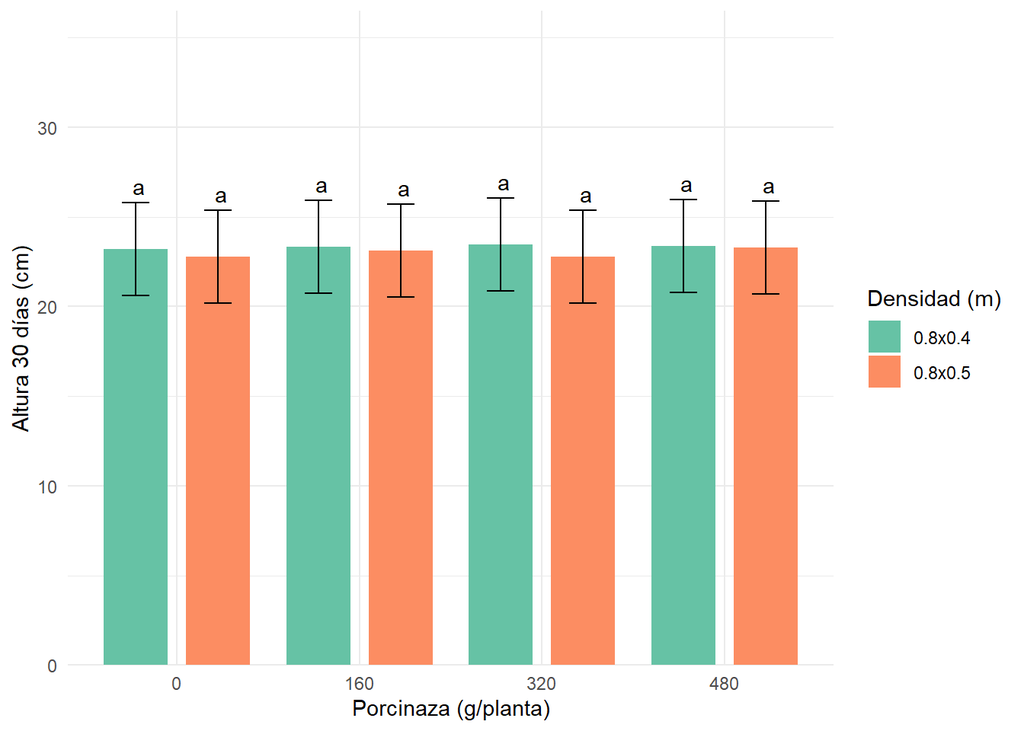

```r
emmeans_altu30d <- emmeans(md_altu30d, ~ porcinaza | densidad)
cld_altu30d <- cld(emmeans_altu30d, adjust = "tukey", Letters = letters)

ggplot(cld_altu30d, aes(x = porcinaza, y = emmean, fill = densidad)) +
  geom_col(position = position_dodge(0.9), width = 0.7) +
  geom_errorbar(aes(ymin = lower.CL, ymax = upper.CL),
                position = position_dodge(0.9), width = 0.3) +
  geom_text(aes(label = .group, y = upper.CL),
            position = position_dodge(0.9), vjust = -0.5) +
  labs(x = "Porcinaza (g/planta)", y = "Altura 30 días (cm)", fill = "Densidad (m)") +
  scale_fill_brewer(type = "qual", palette = "Set2") +
  scale_y_continuous(expand = expansion(mult = c(0, 0.4)), limits = c(0, NA)) +
  theme_minimal()
```

Gráfico 02 : Ningún factor ni combinación de factores tuvo un efecto notable sobre la altura a los 30 días en tu experimento.

### 7.2.5 Modelo estadisticos

$$Altup180d = \mu + bloque + porcinaza + densidad + porcinaza*densidad + e$$
### Análisis de varianza Anova altura de planta a los 180 días

```r
md_alt180d <- lmer(alt180d ~ densidad * porcinaza + (1 | bloque), data = fb)

Anova(md_alt180d)
```

```
Analysis of Deviance Table (Type II Wald chisquare tests)

Response: alt180d
                     Chisq Df Pr(>Chisq)
densidad            0.0903  1     0.7637
porcinaza          23.7844  3  2.771e-05 ***
densidad:porcinaza  0.3293  3     0.9544
---
Signif. codes:  0 '***' 0.001 '**' 0.01 '*' 0.05 '.' 0.1 ' ' 1
```

La altura de planta a los 180 días estuvo determinada principalmente por el nivel de porcinaza aplicada, mientras que la densidad de siembra y la interacción entre factores no afectaron significativamente esta variable.

### 7.2.6 Comparación de medias de altura de planta los 180 días

```r
tukey <- emmeans(md_alt180d, ~ porcinaza*densidad) %>%
  cld(adjust = "tukey", Letters = letters)

print(tukey)
```

```
 porcinaza densidad emmean   SE df lower.CL upper.CL .group
 0         0.8x0.4     188 3.32 24      178      198  a
 0         0.8x0.5     189 3.32 24      179      199  ab
 320       0.8x0.5     196 3.32 24      186      206  abc
 160       0.8x0.4     197 3.32 24      187      207  abc
 320       0.8x0.4     198 3.32 24      188      208  abc
 160       0.8x0.5     199 3.32 24      189      209  abc
 480       0.8x0.4     204 3.32 24      194      214   bc
 480       0.8x0.5     205 3.32 24      195      215    c

Degrees-of-freedom method: kenward-roger
Confidence level used: 0.95
Conf-level adjustment: sidak method for 8 estimates
P value adjustment: tukey method for comparing a family of 8 estimates
significance level used: alpha = 0.05
NOTE: If two or more means share the same grouping symbol,
      then we cannot show them to be different.
      But we also did not show them to be the same.
```

### 7.2.7 Gráficos altura de planta los 180 días

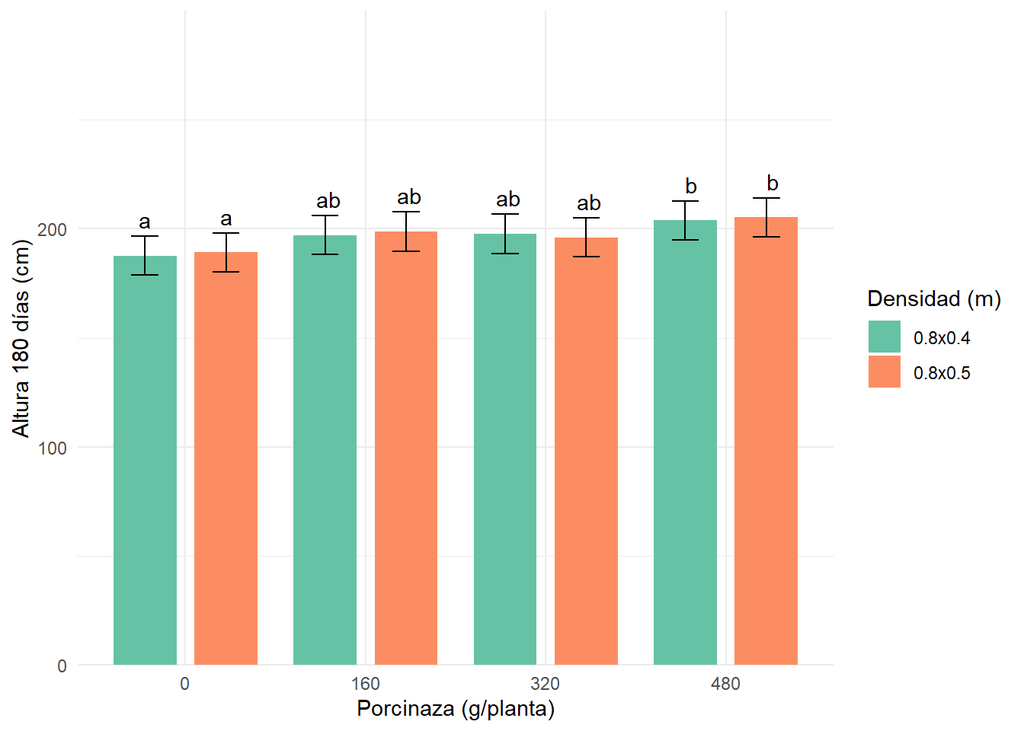

```r
emmeans_alt180d <- emmeans(md_alt180d, ~ porcinaza | densidad)
cld_alt180d <- cld(emmeans_alt180d, adjust = "tukey", Letters = letters)

ggplot(cld_alt180d, aes(x = porcinaza, y = emmean, fill = densidad)) +
  geom_col(position = position_dodge(0.9), width = 0.7) +
  geom_errorbar(aes(ymin = lower.CL, ymax = upper.CL),
                position = position_dodge(0.9), width = 0.3) +
  geom_text(aes(label = .group, y = upper.CL),
            position = position_dodge(0.9), vjust = -0.5) +
  labs(x = "Porcinaza (g/planta)", y = "Altura 180 días (cm)", fill = "Densidad (m)") +
  scale_fill_brewer(type = "qual", palette = "Set2") +
  scale_y_continuous(expand = expansion(mult = c(0, 0.4)), limits = c(0, NA)) +
  theme_minimal()
```

## 7.3 VARIABLE 3 número de mazorcas por planta

### 7.3.1 Modelo estadisticos número de mazorcas por planta

$$Mazp = \mu + bloque + porcinaza + densidad + porcinaza*densidad + e$$

### 7.3.2 Análisis de varianza Anova número de mazorcas por planta

```r
modelo_maz_p <- lmer(maz_p ~ densidad * porcinaza + (1 | bloque), data = fb)

Anova(modelo_maz_p)
```

```
Analysis of Deviance Table (Type II Wald chisquare tests)

Response: maz_p
                      Chisq Df Pr(>Chisq)
densidad           181.5046  1    < 2e-16 ***
porcinaza          132.5262  3    < 2e-16 ***
densidad:porcinaza   8.4646  3    0.03732 *
---
Signif. codes:  0 '***' 0.001 '**' 0.01 '*' 0.05 '.' 0.1 ' ' 1
```

Tanto la densidad de siembra como los niveles de porcinaza tuvieron un efecto altamente significativo en el número de mazorcas por planta. Además, la interacción significativa entre ambos factores indica que las combinaciones específicas de densidad y fertilización orgánica influyen de manera conjunta en la producción de mazorcas.

### 7.3.3 Comparación de medias mazorcas por planta

```r
tukey <- emmeans(modelo_maz_p, ~ porcinaza*densidad) %>%
  cld(adjust = "tukey", Letters = letters)

print(tukey)
```

```
 porcinaza densidad emmean     SE   df lower.CL upper.CL .group
 0         0.8x0.4    1.05 0.0378 20.5    0.935     1.16  a
 160       0.8x0.4    1.07 0.0378 20.5    0.960     1.19  a
 320       0.8x0.4    1.25 0.0378 20.5    1.135     1.36   b
 480       0.8x0.4    1.32 0.0378 20.5    1.210     1.44   b
 0         0.8x0.5    1.32 0.0378 20.5    1.210     1.44   b
 160       0.8x0.5    1.40 0.0378 20.5    1.285     1.51   bc
 320       0.8x0.5    1.52 0.0378 20.5    1.410     1.64    c
 480       0.8x0.5    1.77 0.0378 20.5    1.660     1.89     d

Degrees-of-freedom method: kenward-roger
Confidence level used: 0.95
Conf-level adjustment: sidak method for 8 estimates
P value adjustment: tukey method for comparing a family of 8 estimates
significance level used: alpha = 0.05
NOTE: If two or more means share the same grouping symbol,
      then we cannot show them to be different.
      But we also did not show them to be the same.
```

### 7.3.4 Gráfico de número de mazorcas por planta

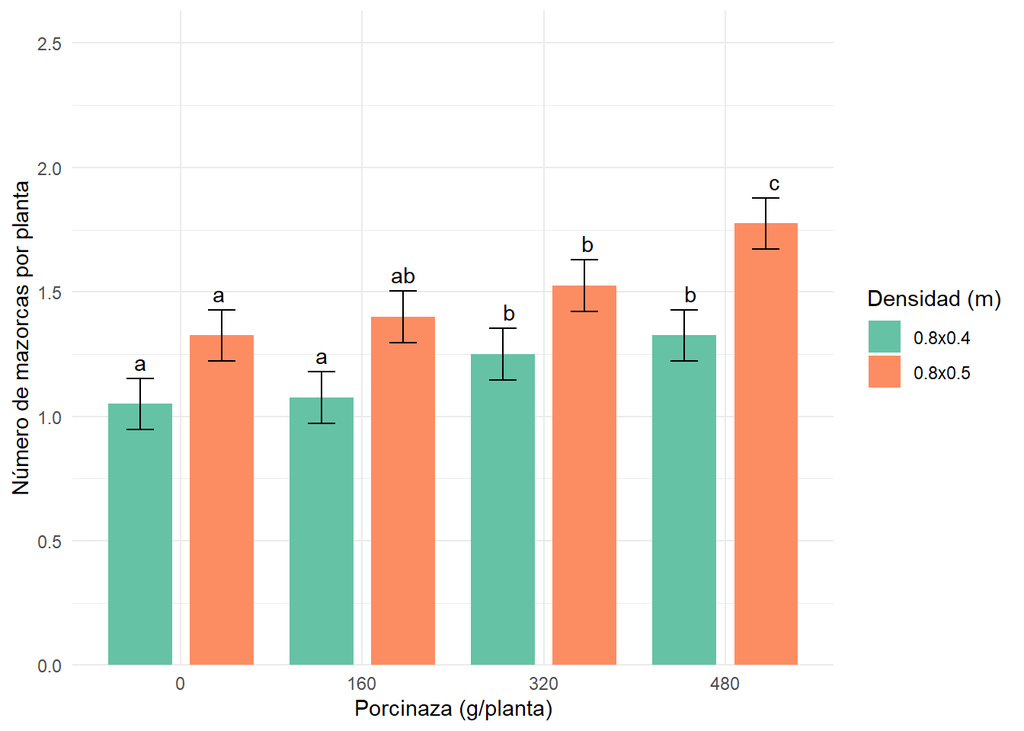

```r
emmeans_var3 <- emmeans(modelo_maz_p, ~ porcinaza | densidad)
cld_var3 <- cld(emmeans_var3, adjust = "tukey", Letters = letters)

ggplot(cld_var3, aes(x = porcinaza, y = emmean, fill = densidad)) +
  geom_col(position = position_dodge(0.9), width = 0.7) +
  geom_errorbar(aes(ymin = lower.CL, ymax = upper.CL),
                position = position_dodge(0.9), width = 0.3) +
  geom_text(aes(label = .group, y = upper.CL),
            position = position_dodge(0.9), vjust = -0.5) +
  labs(x = "Porcinaza (g/planta)", y = "Número de mazorcas por planta", fill = "Densidad (m)") +
  scale_fill_brewer(type = "qual", palette = "Set2") +
  scale_y_continuous(expand = expansion(mult = c(0, 0.4)), limits = c(0, NA)) +
  theme_minimal()
```

# 8 ANÁLISIS MULTIVARIADO PCA

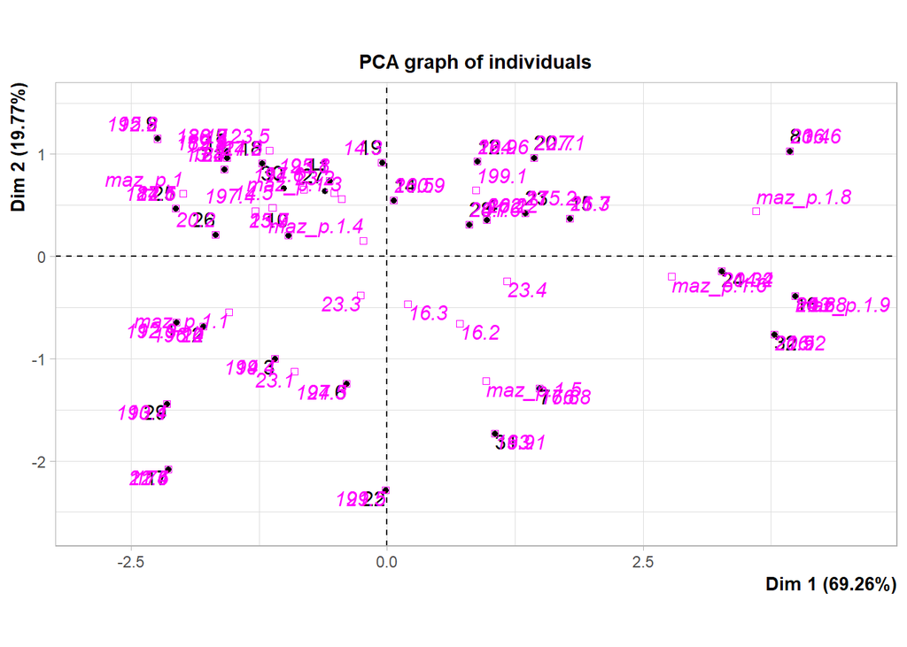

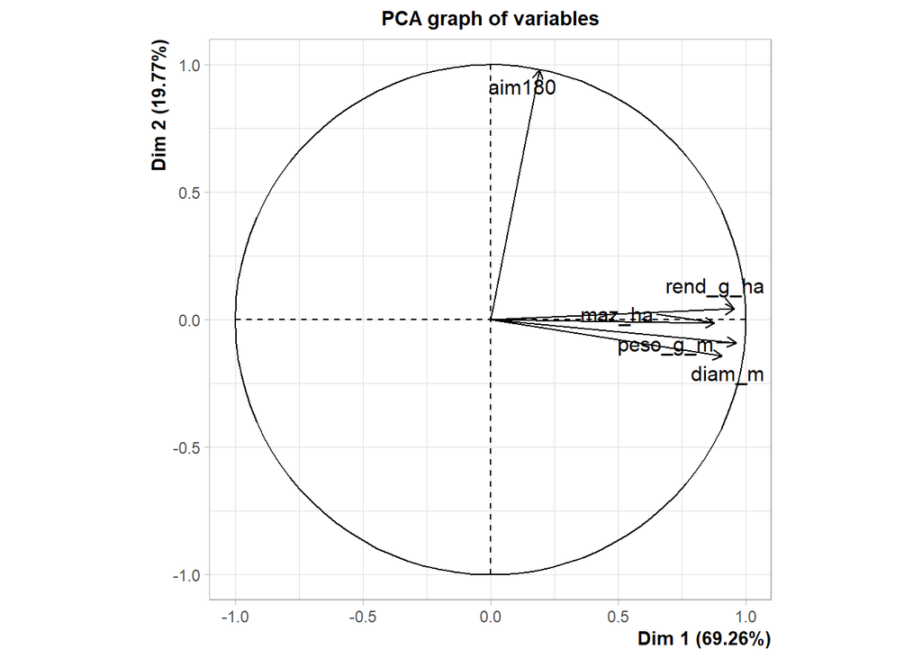

```
**Results for the Principal Component Analysis (PCA)**
The analysis was performed on 32 individuals, described by 9 variables
*The results are available in the following objects:

   name                description
1  "$eig"              "eigenvalues"
2  "$var"              "results for the variables"
3  "$var$coord"        "coord. for the variables"
4  "$var$cor"          "correlations variables - dimensions"
5  "$var$cos2"         "cos2 for the variables"
6  "$var$contrib"      "contributions of the variables"
7  "$ind"              "results for the individuals"
8  "$ind$coord"        "coord. for the individuals"
9  "$ind$cos2"         "cos2 for the individuals"
10 "$ind$contrib"      "contributions of the individuals"
11 "$quali.sup"        "results for the supplementary categorical variables"
12 "$quali.sup$coord"  "coord. for the supplementary categories"
13 "$quali.sup$v.test" "v-test of the supplementary categories"
14 "$call"             "summary statistics"
15 "$call$centre"      "mean of the variables"
16 "$call$ecart.type"  "standard error of the variables"
17 "$call$row.w"       "weights for the individuals"
18 "$call$col.w"       "weights for the variables"
```

```r
PCA(fb[, 5:13], quali.sup = 1:4, graph = T)
```

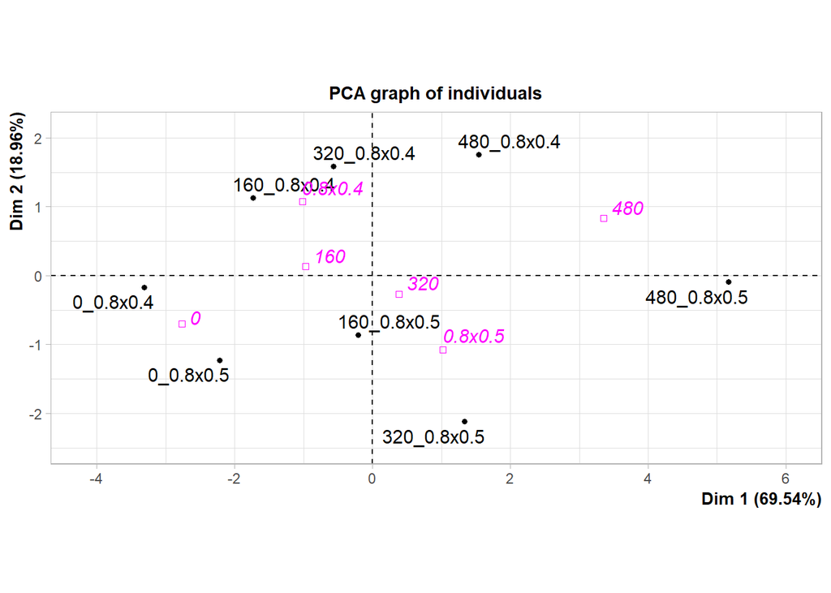

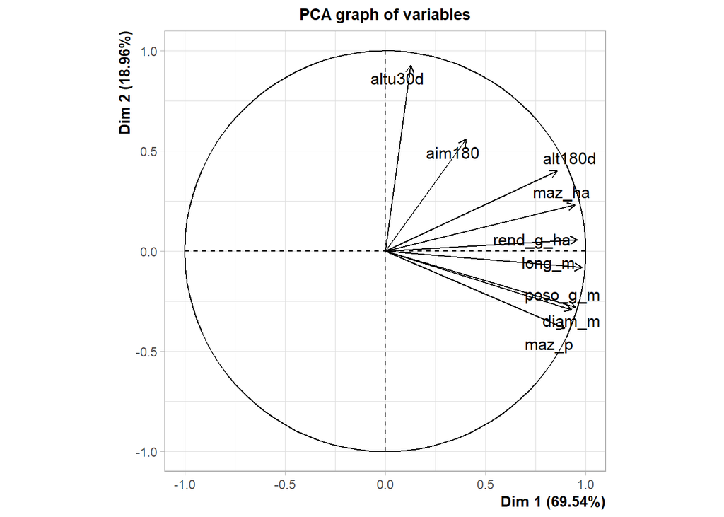

```r
dtmv <- fb %>%
  group_by(porcinaza, densidad) %>%
  summarise(across(where(is.numeric)
                   , ~ mean(., na.rm = T))) %>%
  unite("trat", c(porcinaza, densidad), remove = F) %>%
  column_to_rownames("trat")
  pca <- PCA(X = dtmv, scale.unit = T
           , quali.sup = c(1, 2))
```

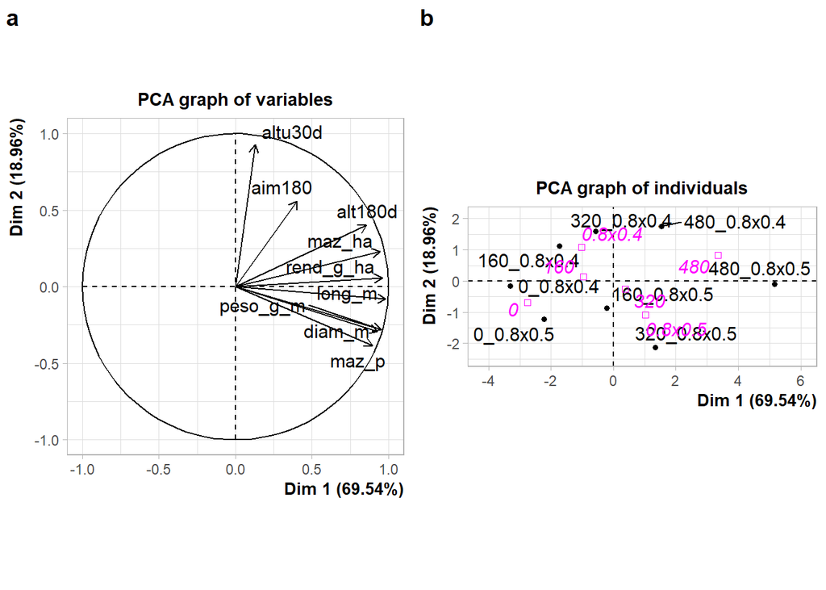

```r
var <- plot(pca, choix = "var")

ind <- plot(pca, choix = "ind")

list(var, ind) %>%
  plot_grid(plotlist =., ncol = 2, labels = "auto")
```

Gráficos 05 : PCA mostró una alta asociación entre las variables de rendimiento (maz_p, maz_ha, diam_m, peso_g y long_m). Los tratamientos con 480 g/planta, especialmente con densidad 0.8×0.5 m, se ubicaron en la zona de mayor productividad, mientras que los sin porcinaza presentaron menor desempeño.

## 8.1 Gráfico de correlación

```r
library(GGally)

ggplot(dtmv, aes(x = NULL, y = NULL)) + geom_blank() + theme_void()
```

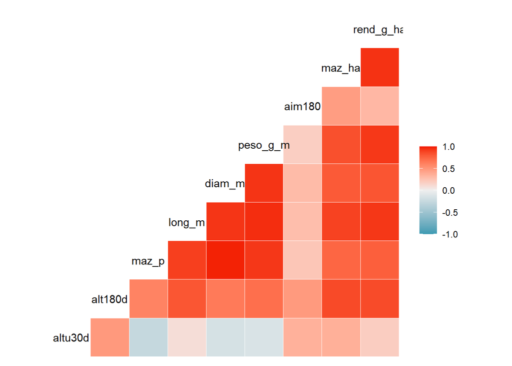

```r
ggcorr(dtmv %>% dplyr::select(where(is.numeric)))
```

Gráfico 06 : El gráfico muestra la relación entre las variables agronómicas del experimento. Se observa una fuerte correlación positiva (en tonos rojos) entre el rendimiento (rend_g_ha) y variables como mazorcas por hectárea (maz_ha), peso, diámetro y longitud de mazorca, indicando que estos componentes determinan directamente la productividad.

# 9 REFERENCIA BIBLIOGRÁFICA

Olasco-Bernardo, Y., Gutiérrez-Solórzano, M. B., Palacín-Guerra, P. S., & Cornejo-Maldonado, A. S. (2022). Enmiendas orgánicas y su efecto en los componentes de rendimiento de maíz morado (Zea mays L.) en Huánuco, Perú. Revista Investigación Agraria, 4 (1), 38-45. https://doi.org/10.47840/ReInA.4.1.1314

Zagaceta Llanca (2023). Niveles de porcinaza y densidades de siembra sobre el rendimiento de maíz morado (Zea mays L.) var. INIA-601 en Lámud.